# Biodiversity Surveys: Plant and Bird Communities in the Pomona College Wash

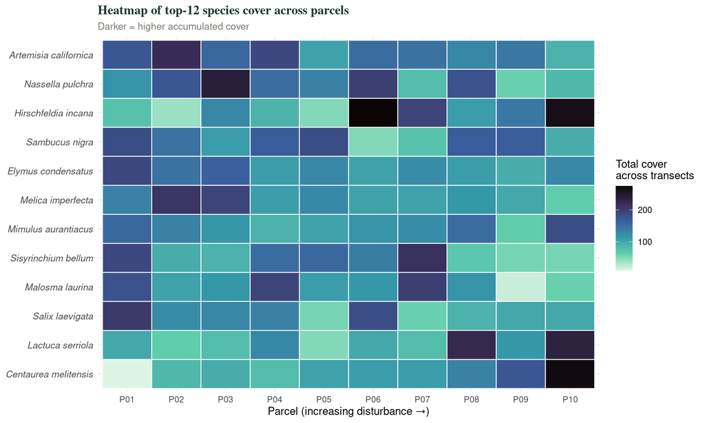

```r
# Find the 12 most abundant species overall to display on the heatmap
top_species <- colSums(comm_wide) %>%
  sort(decreasing = TRUE) %>%
  head(12) %>%
  names()

comm_top <- comm_wide[, top_species] %>%
  as.data.frame() %>%
  rownames_to_column("parcel_id") %>%
  pivot_longer(-parcel_id, names_to = "species", values_to = "cover") %>%
  left_join(parcel_meta, by = "parcel_id") %>%
  mutate(
    parcel_id = fct_reorder(parcel_id, disturbance),
    species   = fct_reorder(species, cover, .fun = sum)
  )

ggplot(comm_top,
       aes(x = parcel_id, y = species, fill = cover)) +
  geom_tile(color = "white", linewidth = 0.4) +
  scale_fill_viridis_c(
    option = "mako", direction = -1,
    name   = "Total cover\nacross transects"
  ) +
  labs(
    title    = "Heatmap of top-12 species cover across parcels",
    subtitle = "Darker = higher accumulated cover",
    x = "Parcel (increasing disturbance →)",
    y = NULL
  ) +
  theme_minimal(base_size = 11) +
  theme(
    plot.title    = element_text(family = "serif", face = "bold",
                                 color = "#1e3a2f", size = 13),
    plot.subtitle = element_text(color = "#7a7a72", size = 10),
    axis.text.y   = element_text(face = "italic", size = 9.5),
    legend.position = "right"
  )
```

## 7. Multivariate Ordination with NMDS

Diversity indices and composition charts treat each species individually. But **community composition is multivariate** — a parcel is characterized by its pattern across all 28 species simultaneously. Ordination techniques reduce this high-dimensional space to a low-dimensional representation that preserves the relative (dis)similarities among parcels.

### 7.1 Why NMDS?

**Non-metric multidimensional scaling (NMDS)** is the preferred ordination method for community ecology because it makes no assumptions about linearity or normality. It works purely on **ranks** of pairwise dissimilarities (usually Bray-Curtis) and tries to represent those ranks faithfully in 2D space.

**⚙️ Bray-Curtis dissimilarity**  
BC<sub>ij</sub> = 1 − 2 × Σ min(n<sub>ik</sub>, n<sub>jk</sub>) / (Σ n<sub>ik</sub> + Σ n<sub>jk</sub>)  
Where n<sub>ik</sub> is the abundance of species k in site i. BC = 0 when two sites share identical composition; BC = 1 when they share no species. Bray-Curtis is preferred over Euclidean distance for community data because it is unaffected by joint absences — two sites that both lack a rare species should not be considered “more similar” because of it.

### 7.2 Run NMDS

```r
# Use Hellinger-transformed cover to down-weight dominant species
comm_hel <- decostand(comm_wide, method = "hellinger")

set.seed(42)   # NMDS is stochastic; setting a seed makes results reproducible
nmds_result <- metaMDS(
  comm_hel,
  distance = "bray",
  k        = 2,     # 2 dimensions
  trymax   = 100,   # maximum random starts
  autotransform = FALSE   # we already transformed
)
```

```r
cat("NMDS stress:", round(nmds_result$stress, 4), "\n")
```

```
## NMDS stress: 0.0709
```

**📌 What is stress?** Stress measures how well the 2D ordination preserves the rank-order of pairwise dissimilarities from the full multivariate space. Lower is better:

- Stress < 0.10 — excellent representation
- Stress 0.10–0.20 — good; minor distortions
- Stress 0.20–0.30 — suspect; consider 3 dimensions or interpret cautiously
- Stress > 0.30 — poor fit; ordination is unreliable

### 7.3 Plot the ordination

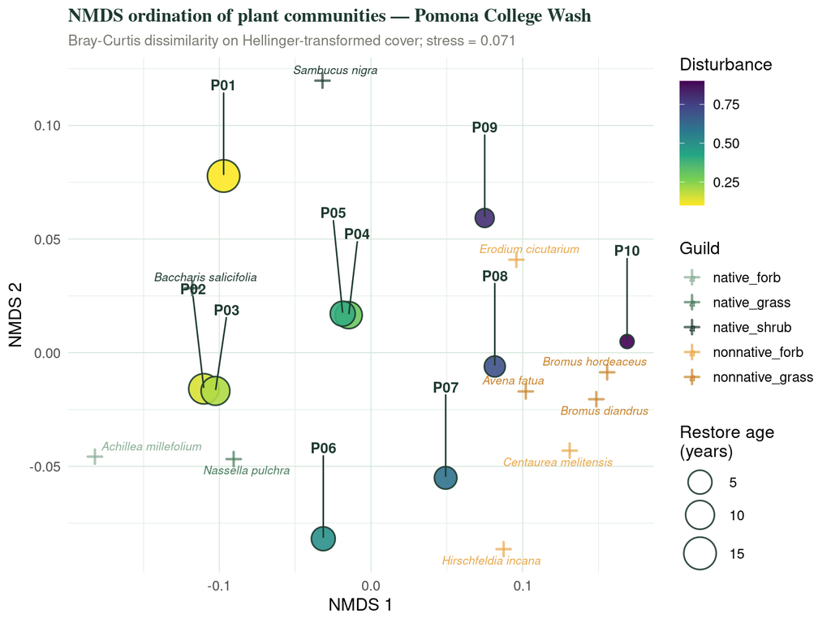

```r
# Extract site scores (parcel positions in 2D space)
site_scores <- scores(nmds_result, display = "sites") %>%
  as.data.frame() %>%
  rownames_to_column("parcel_id") %>%
  left_join(parcel_meta, by = "parcel_id")

# Extract species scores (species positions — shows which species drive separation)
spp_scores <- scores(nmds_result, display = "species") %>%
  as.data.frame() %>%
  rownames_to_column("species") %>%
  left_join(species_pool, by = "species") %>%
  # Display only the 10 species most strongly positioned
  mutate(vec_len = sqrt(NMDS1^2 + NMDS2^2)) %>%
  slice_max(vec_len, n = 10)

ggplot() +
  # Species points and labels
  geom_point(data = spp_scores,
             aes(x = NMDS1, y = NMDS2, color = guild),
             shape = 3, size = 2.5, stroke = 1.2, alpha = 0.7) +
  geom_text_repel(data = spp_scores,
                  aes(x = NMDS1, y = NMDS2, label = species, color = guild),
                  size = 2.8, fontface = "italic", max.overlaps = 20,
                  segment.color = "grey70", segment.size = 0.3) +
  # Parcel points — sized by restoration age
  geom_point(data = site_scores,
             aes(x = NMDS1, y = NMDS2, fill = disturbance,
                 size = restore_age_yr),
             shape = 21, color = "#1e3a2f", stroke = 0.8, alpha = 0.9) +
  geom_text_repel(data = site_scores,
                  aes(x = NMDS1, y = NMDS2, label = parcel_id),
                  size = 3.5, fontface = "bold", color = "#1e3a2f",
                  nudge_y = 0.04) +
  scale_fill_viridis_c(
    option = "viridis", direction = -1,
    name   = "Disturbance"
  ) +
  scale_color_manual(
    values = c(
      "native_shrub"    = "#1e3a2f",
      "native_grass"    = "#4a7c5e",
      "native_forb"     = "#8aad96",
      "nonnative_grass" = "#c8832a",
      "nonnative_forb"  = "#e8a84a"
    ),
    name = "Guild"
  ) +
  scale_size_continuous(name = "Restore age\n(years)", range = c(4, 10)) +
  labs(
    title    = "NMDS ordination of plant communities — Pomona College Wash",
    subtitle = paste0("Bray-Curtis dissimilarity on Hellinger-transformed cover; stress = ",
                      round(nmds_result$stress, 3)),
    x = "NMDS 1", y = "NMDS 2"
  ) +
  theme_minimal(base_size = 12) +
  theme(
    plot.title    = element_text(family = "serif", face = "bold",
                                 color = "#1e3a2f", size = 13),
    plot.subtitle = element_text(color = "#7a7a72", size = 10),
    legend.position = "right",
    panel.grid    = element_line(color = "#d4e6da", linewidth = 0.3)
  )
```

**📌 How to read an NMDS biplot**

- **Parcel points (circles)**: parcels that are closer together have more similar species composition. Parcels that are far apart are compositionally very different.
- **Species markers (crosses)**: a species positioned close to a parcel is abundant in that parcel. Species near the center are widespread across all parcels.
- **Axes have no inherent meaning**: NMDS1 and NMDS2 are not “latent variables” — do not interpret their direction or units. Only distances between points matter.

### 7.4 Shepard plot: assessing ordination quality

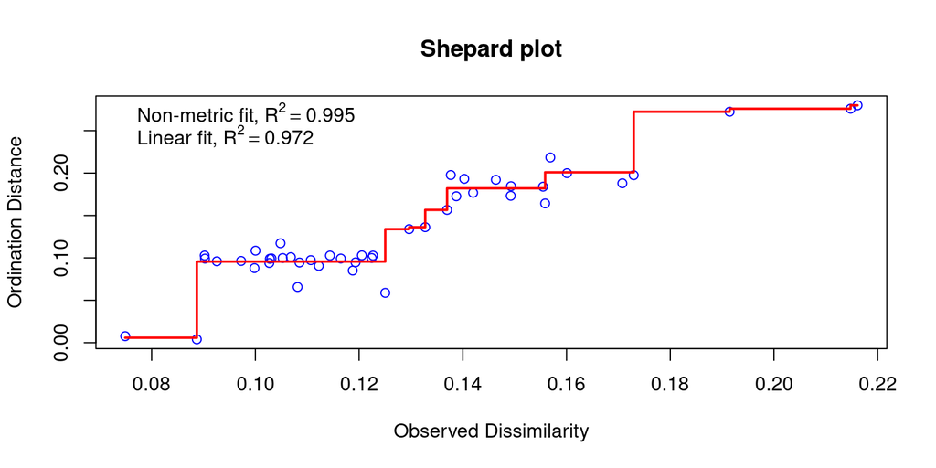

```r
# The Shepard diagram plots ranked real dissimilarities against
# distances in the ordination — good fit = tight, monotone scatter
stressplot(nmds_result, main = "Shepard plot")
```

## 8. PERMANOVA: Do Communities Differ Among Parcels?

The ordination suggests parcels differ in composition, but is that difference statistically significant? **PERMANOVA** (permutational MANOVA; `adonis2()` in vegan) tests whether the within-group variance is significantly smaller than among-group variance, using random permutations of the data to generate a null distribution.

### 8.1 Do disturbance categories explain community composition?

```r
# Create a categorical disturbance group (low / medium / high)
parcel_meta_cats <- parcel_meta %>%
  mutate(
    dist_cat = cut(
      disturbance,
      breaks = c(0, 0.33, 0.66, 1.0),
      labels = c("low", "medium", "high"),
      include.lowest = TRUE
    )
  )

# Match order to comm_wide rows
meta_ordered <- parcel_meta_cats[match(rownames(comm_wide),
                                       parcel_meta_cats$parcel_id), ]

set.seed(99)
perm_result <- adonis2(
  comm_hel ~ dist_cat,
  data   = meta_ordered,
  method = "bray",
  permutations = 999
)

print(perm_result)
```

```
## Permutation test for adonis under reduced model
## Permutation: free
## Number of permutations: 999
##
## adonis2(formula = comm_hel ~ dist_cat, data = meta_ordered, permutations = 999, method = "bray")
##          Df SumOfSqs     R2      F Pr(>F)
## Model     2 0.039698 0.5083 3.6181  0.003 **
## Residual  7 0.038402 0.4917
## Total     9 0.078100 1.0000
## ---
## Signif. codes:  0 '***' 0.001 '**' 0.01 '*' 0.05 '.' 0.1 ' ' 1
```

**📌 Interpreting PERMANOVA output**

### 8.2 Test for homogeneity of dispersion

```r
# Calculate Bray-Curtis distance matrix
bc_dist <- vegdist(comm_hel, method = "bray")

# betadisper tests whether variance *within* groups differs
disp_result <- betadisper(bc_dist, meta_ordered$dist_cat)
anova(disp_result)
```

```
## Analysis of Variance Table
##
## Response: Distances
##           Df     Sum Sq    Mean Sq F value Pr(>F)
## Groups     2 0.00002761 1.3804e-05  0.0951 0.9104
## Residuals  7 0.00101612 1.4516e-04
```

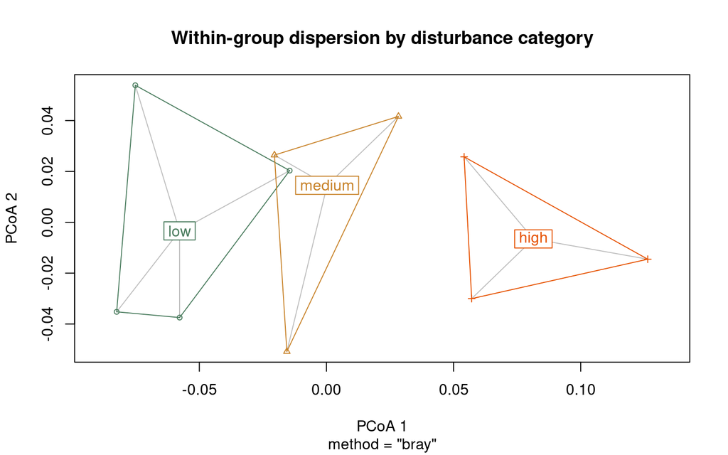

```r
plot(disp_result, main = "Within-group dispersion by disturbance category",
     col = c("#4a7c5e", "#c8832a", "#e65100"))
```

**⚠️ Dispersion ≠ composition** A significant PERMANOVA result could reflect genuine differences in species composition *or* differences in within-group variability (dispersion). If `betadisper` returns a significant result, the two effects are confounded and you should report both tests and discuss this limitation. If dispersion is homogeneous (non-significant), the PERMANOVA result is unambiguous.

## 9. Summary and Interpretation

```r
# Compile all metrics into one summary table
summary_tbl <- div_wide %>%
  select(parcel_id, disturbance, restore_age_yr, `Shannon H'`, `Simpson 1−D`) %>%
  left_join(
    tibble(parcel_id = names(rare_S),
           rarefied_S = round(as.numeric(rare_S), 1)),
    by = "parcel_id"
  ) %>%
  arrange(disturbance) %>%
  mutate(across(where(is.numeric), ~ round(.x, 2)))

summary_tbl %>%
  kbl(
    caption = "Summary of diversity metrics across Wash parcels (ordered by disturbance)",
    col.names = c("Parcel", "Disturbance", "Restore age (yr)",
                  "Shannon H'", "Simpson 1−D", "Rarefied S")
  ) %>%
  kable_styling(bootstrap_options = c("striped", "hover", "condensed"),
                full_width = FALSE) %>%
  column_spec(2, color = "white",
              background = spec_color(summary_tbl$disturbance,
                                      palette = "viridis",
                                      direction = -1))
```

Summary of diversity metrics across Wash parcels (ordered by disturbance)

| Parcel | Disturbance | Restore age (yr) | Shannon H’ | Simpson 1−D | Rarefied S |
| --- | --- | --- | --- | --- | --- |
| P01 | 0.10 | 15 | 3.20 | 0.96 | 28 |
| P02 | 0.15 | 12 | 3.21 | 0.96 | 28 |
| P03 | 0.20 | 10 | 3.24 | 0.96 | 28 |
| P04 | 0.30 | 8 | 3.28 | 0.96 | 28 |
| P05 | 0.40 | 6 | 3.27 | 0.96 | 28 |
| P06 | 0.50 | 5 | 3.24 | 0.96 | 28 |
| P07 | 0.60 | 4 | 3.26 | 0.96 | 28 |
| P08 | 0.70 | 3 | 3.25 | 0.96 | 28 |
| P09 | 0.80 | 2 | 3.25 | 0.96 | 28 |
| P10 | 0.90 | 1 | 3.20 | 0.96 | 28 |

#### 💬 Discussion questions

1. P05 and P06 have similar disturbance scores but different Shannon diversity values. What ecological processes might explain this discrepancy beyond simple disturbance intensity?
2. The rarefaction curves for some high-disturbance parcels plateau quickly. What does a fast-flattening curve tell you about the community structure of those parcels?
3. NMDS axes have no inherent meaning. How would you communicate the ordination results to a non-technical audience — for example, a Pomona College land manager deciding where to prioritize restoration investment?
4. If you were designing a follow-up field survey to validate these results, what additional variables would you measure along each transect and why?
5. The PERMANOVA tests whether communities differ among disturbance categories. Why is it important to also run `betadisper()`? Give an example of how a significant dispersion result would change your interpretation.

Part II

Bird Community Surveys

Point-count surveys across the same 10 parcels • detection-based counts • foraging guilds • avian diversity indices • cross-taxa comparison

## 10. Part II — Bird Surveys in the Wash

Birds are ideal biodiversity indicators for riparian corridors: they respond rapidly to changes in vegetation structure, are detectable by sight and sound, and their assemblages integrate conditions across large spatial scales. Point-count surveys are the standard field method — a trained observer stands at a fixed location for a fixed time and records every bird detected within a defined radius.

The same 10 parcels surveyed for plants were each visited **6 times** across the breeding season (March–June). At each visit, **3 point-count stations** were established within the parcel, and all birds detected within **25 m** during a **5-minute count** were recorded with species, count, detection method (visual/auditory), and distance band. This gives us 10 parcels × 6 visits × 3 stations = 180 count records per species.

**📌 Why count birds differently from plants?** Plants stay put — you can measure their cover precisely. Birds move, hide, and sing from concealed locations. Point counts capture *detections*, not true abundance. Two important consequences: (1) detection probability varies by species, habitat, and observer; and (2) the same individual can theoretically be counted at multiple stations. In a full occupancy-modeling framework (see the Camera Trap module) we would formally estimate detection probability. Here we treat detection counts as an index of relative abundance, which is appropriate for comparing across parcels where conditions are broadly similar.

### 10.1 The bird analytical pipeline

Stage 1

Simulate & Import

Generate realistic point-count data for 35 bird species from the Wash / BFS checklist.

Stage 2

Detection Summary

Total detections per species, visit-level completeness, naïve occupancy.

Stage 3

Richness & Rarefaction

Species richness per parcel; rarefy to equal visit effort before comparing.

Stage 4

Foraging Guilds

Classify species into functional foraging guilds; compare guild composition across the disturbance gradient.

Stage 5

NMDS Ordination

Bray-Curtis NMDS of bird assemblages; overlay vegetation structure covariates with envfit.

Stage 6

Cross-taxa Test

Does avian diversity track plant diversity across parcels? Mantel test for matrix correlation.

## 11. Bird Data Simulation

### 11.1 The species pool

The bird species list is drawn from the Bernard Field Station checklist and eBird records from the Claremont area, filtered to species that regularly use riparian scrub and grassland habitat.

```r
bird_pool <- tibble(
  species = c(
    # Riparian obligates and specialists
    "Empidonax traillii",         # Willow Flycatcher – riparian obligate
    "Geothlypis trichas",         # Common Yellowthroat
    "Cistothorus palustris",      # Marsh Wren
    "Agelaius phoeniceus",        # Red-winged Blackbird
    "Melospiza melodia",          # Song Sparrow
    # Shrub/scrub species
    "Chamaea fasciata",           # Wrentit – chaparral indicator
    "Polioptila californica",     # California Gnatcatcher (threatened)
    "Toxostoma redivivum",        # California Thrasher
    "Pipilo maculatus",           # Spotted Towhee
    "Melozone crissalis",         # California Towhee
    "Artemisiospiza belli",       # Bell's Sparrow
    "Passerculus sandwichensis",  # Savannah Sparrow
    # Aerial insectivores
    "Petrochelidon pyrrhonota",   # Cliff Swallow
    "Hirundo rustica",            # Barn Swallow
    "Tachycineta bicolor",        # Tree Swallow
    "Chaetura vauxi",             # Vaux's Swift
    # Generalist passerines / edge species
    "Mimus polyglottos",          # Northern Mockingbird
    "Sturnus vulgaris",           # European Starling (invasive)
    "Passer domesticus",          # House Sparrow (invasive)
    "Spinus psaltria",            # Lesser Goldfinch
    "Haemorhous mexicanus",       # House Finch
    "Poecile rufescens",          # Chestnut-backed Chickadee
    "Sitta canadensis",           # Red-breasted Nuthatch
    # Foragers / omnivores
    "Corvus brachyrhynchos",      # American Crow
    "Aphelocoma californica",     # California Scrub-Jay
    "Turdus migratorius",         # American Robin
    "Catharus ustulatus",         # Swainson's Thrush (migrant)
    # Raptors / predators
    "Buteo jamaicensis",          # Red-tailed Hawk
    "Accipiter cooperii",         # Cooper's Hawk
    "Falco sparverius",           # American Kestrel
    "Tyto alba",                  # Barn Owl
    # Ground foragers
    "Zenaida macroura",           # Mourning Dove
    "Geococcyx californianus",    # Greater Roadrunner
    "Picoides pubescens",         # Downy Woodpecker
    "Melanerpes formicivorus"     # Acorn Woodpecker
  ),
  # Foraging guild assignment
  guild_bird = c(
    rep("riparian_specialist", 5),
    rep("shrub_scrub",         6),
    rep("aerial_insectivore",  4),
    rep("generalist",          7),
    rep("omnivore",            4),
    rep("raptor",              4),
    rep("ground_forager",      5)
  ),
  # Sensitivity to disturbance: 1 = avoids disturbed, -1 = favors disturbed
  disturbance_response = c(
    # riparian specialists — strongly avoid disturbance
     1,  1,  1,  0.5,  0.5,
    # shrub/scrub — avoid disturbance
     1,  1,  0.8, 0.6, 0.4, 0.3,
    # aerial insectivores — neutral to slight preference for open
    -0.2, -0.2, -0.2, -0.3,
    # generalists — variable, invasives favor disturbance
     0.2, -0.8, -0.8,  0.3,  0.1,  0.4,  0.5,
    # omnivores — slight disturbance avoidance
     0.4,  0.3,  0.2,  0.3,
    # raptors — neutral to open habitat
    -0.1, -0.2, -0.3, -0.1,
    # ground foragers
    -0.2,  0.3, 0.4, 0.2, 0.2
  )
)

cat("Bird species in pool:", nrow(bird_pool), "\n")
```

```
## Bird species in pool: 35
```

```r
cat("Foraging guilds:", paste(unique(bird_pool$guild_bird), collapse = ", "), "\n")
```

```
## Foraging guilds: riparian_specialist, shrub_scrub, aerial_insectivore, generalist, omnivore, raptor, ground_forager
```

### 11.2 Simulate point-count records

```r
set.seed(2025)

n_visits   <- 6     # survey visits per parcel
n_stations <- 3     # point-count stations per parcel visit

simulate_pointcount <- function(parcel_id, disturbance) {
  map_dfr(1:n_visits, function(visit) {
    map_dfr(1:n_stations, function(station) {
      # Detection probability for each species given this parcel's disturbance
      # Higher disturbance_response → higher p in low-disturbance parcels
      base_p <- 0.35 - disturbance * 0.18 * bird_pool$disturbance_response
      det_p  <- pmin(0.85, pmax(0.02, base_p))

      # Did each species occur? (Bernoulli draw)
      detected <- rbinom(nrow(bird_pool), 1, det_p)

      # Count given detection: negative binomial (overdispersed counts typical of birds)
      counts <- ifelse(detected == 1,
                       rnbinom(nrow(bird_pool), size = 1.5, mu = 2.8) + 1,
                       0L)

      tibble(
        parcel_id  = parcel_id,
        visit      = visit,
        station    = station,
        species    = bird_pool$species,
        guild_bird = bird_pool$guild_bird,
        count      = counts
      ) %>%
        filter(count > 0)
    })
  })
}

bird_raw <- parcel_meta %>%
  pmap_dfr(function(parcel_id, restore_age_yr, disturbance) {
    simulate_pointcount(parcel_id, disturbance)
  })

glimpse(bird_raw)
```

```
## Rows: 2,065
## Columns: 6
## $ parcel_id  <chr> "P01", "P01", "P01", "P01", "P01", "P01", "P01", "P01", "P0…
## $ visit      <int> 1, 1, 1, 1, 1, 1, 1, 1, 1, 1, 1, 1, 1, 1, 1, 1, 1, 1, 1, 1,…
## $ station    <int> 1, 1, 1, 1, 1, 1, 1, 1, 1, 1, 1, 1, 1, 2, 2, 2, 2, 2, 2, 2,…
## $ species    <chr> "Empidonax traillii", "Melospiza melodia", "Polioptila cali…
## $ guild_bird <chr> "riparian_specialist", "riparian_specialist", "shrub_scrub"…
## $ count      <dbl> 3, 1, 1, 5, 2, 6, 3, 4, 5, 6, 7, 1, 2, 8, 3, 1, 3, 1, 3, 1,…
```

## 12. Exploring the Bird Data

### 12.1 Detection totals per species

Which species were detected most frequently across all parcels and visits?

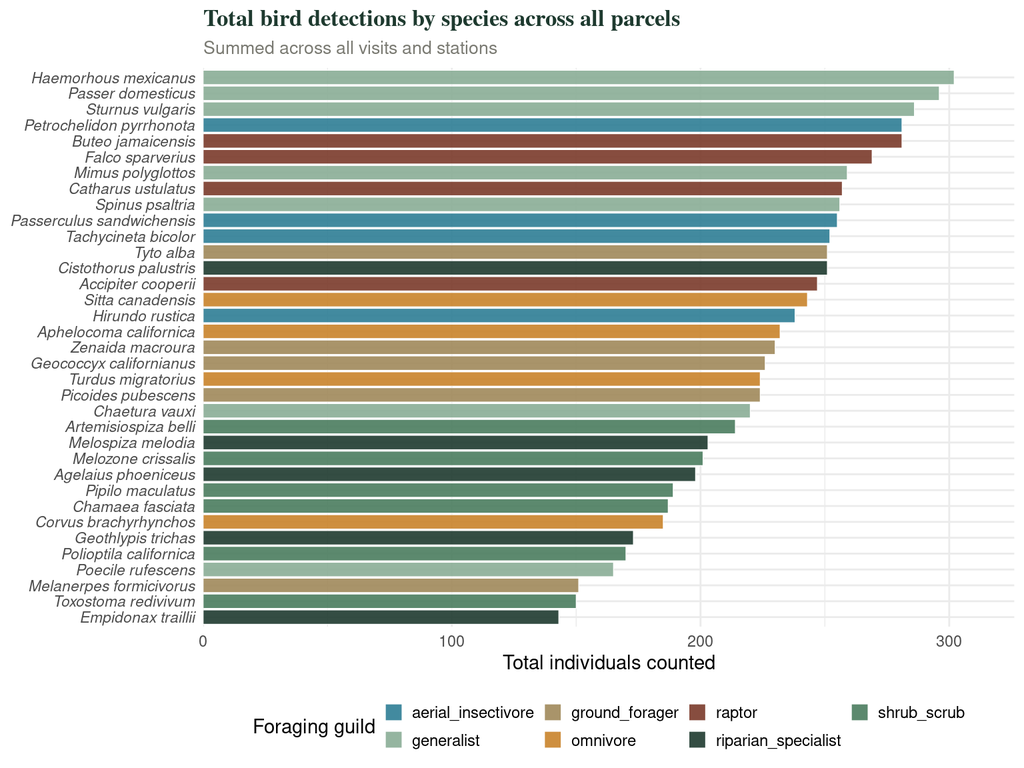

```r
bird_totals <- bird_raw %>%
  group_by(species, guild_bird) %>%
  summarise(
    total_count    = sum(count),
    n_detections   = n(),           # number of station-visits with ≥ 1 bird
    n_parcels      = n_distinct(parcel_id),
    .groups = "drop"
  ) %>%
  arrange(desc(total_count))

guild_bird_colors <- c(
  "riparian_specialist" = "#1e3a2f",
  "shrub_scrub"         = "#4a7c5e",
  "aerial_insectivore"  = "#2e7d94",
  "generalist"          = "#8aad96",
  "omnivore"            = "#c8832a",
  "raptor"              = "#7a3a2a",
  "ground_forager"      = "#a0885a"
)

ggplot(bird_totals,
       aes(x = reorder(species, total_count),
           y = total_count, fill = guild_bird)) +
  geom_col(color = "white", linewidth = 0.2, alpha = 0.9) +
  coord_flip() +
  scale_fill_manual(values = guild_bird_colors, name = "Foraging guild") +
  scale_y_continuous(expand = expansion(mult = c(0, 0.08))) +
  labs(
    title    = "Total bird detections by species across all parcels",
    subtitle = "Summed across all visits and stations",
    x = NULL, y = "Total individuals counted"
  ) +
  theme_minimal(base_size = 11) +
  theme(
    plot.title      = element_text(family = "serif", face = "bold",
                                   color = "#1e3a2f", size = 13),
    plot.subtitle   = element_text(color = "#7a7a72", size = 10),
    axis.text.y     = element_text(face = "italic", size = 8.5),
    legend.position = "bottom",
    legend.key.size = unit(0.35, "cm"),
    legend.text     = element_text(size = 9)
  )
```

### 12.2 Build the bird community matrix

For community analyses, we need a matrix of total counts per species per parcel (summed across all visits and stations).

```r
# Aggregate: total count per parcel × species
bird_parcel <- bird_raw %>%
  group_by(parcel_id, species) %>%
  summarise(total_count = sum(count), .groups = "drop")

# Pivot to wide format
bird_wide <- bird_parcel %>%
  pivot_wider(
    names_from  = species,
    values_from = total_count,
    values_fill = 0L
  ) %>%
  column_to_rownames("parcel_id")

dim(bird_wide)
```

```
## [1] 10 35
```

```r
cat("Parcels × species:", paste(dim(bird_wide), collapse = " × "), "\n")
```

```
## Parcels × species: 10 × 35
```

### 12.3 Bird species richness per parcel

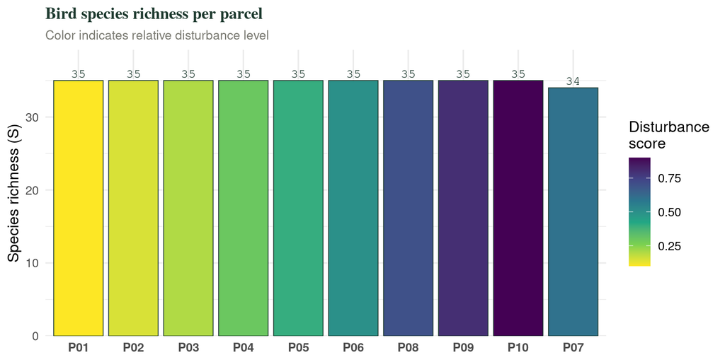

```r
bird_richness <- tibble(
  parcel_id = rownames(bird_wide),
  S_birds   = specnumber(bird_wide)
) %>%
  left_join(parcel_meta, by = "parcel_id")

ggplot(bird_richness,
       aes(x = reorder(parcel_id, -S_birds),
           y = S_birds, fill = disturbance)) +
  geom_col(color = "#1e3a2f", linewidth = 0.3) +
  geom_text(aes(label = S_birds), vjust = -0.4,
            family = "mono", size = 3.5, color = "#1e3a2f") +
  scale_fill_viridis_c(option = "viridis", direction = -1,
                       name = "Disturbance\nscore") +
  scale_y_continuous(expand = expansion(mult = c(0, 0.12))) +
  labs(
    title    = "Bird species richness per parcel",
    subtitle = "Color indicates relative disturbance level",
    x = NULL, y = "Species richness (S)"
  ) +
  theme_minimal(base_size = 12) +
  theme(
    plot.title    = element_text(family = "serif", face = "bold",
                                 color = "#1e3a2f", size = 13),
    plot.subtitle = element_text(color = "#7a7a72", size = 10),
    axis.text.x   = element_text(face = "bold")
  )
```

### 12.4 Rarefaction of bird counts

Bird rarefaction standardizes for sampling effort — here, total individuals counted per parcel.

[figure not shown]

```r
bird_int <- round(bird_wide)
bird_std_n <- min(rowSums(bird_int))

bird_rare_list <- rarecurve(bird_int, step = 10,
                             sample = bird_std_n,
                             label = FALSE, plot = FALSE)
```

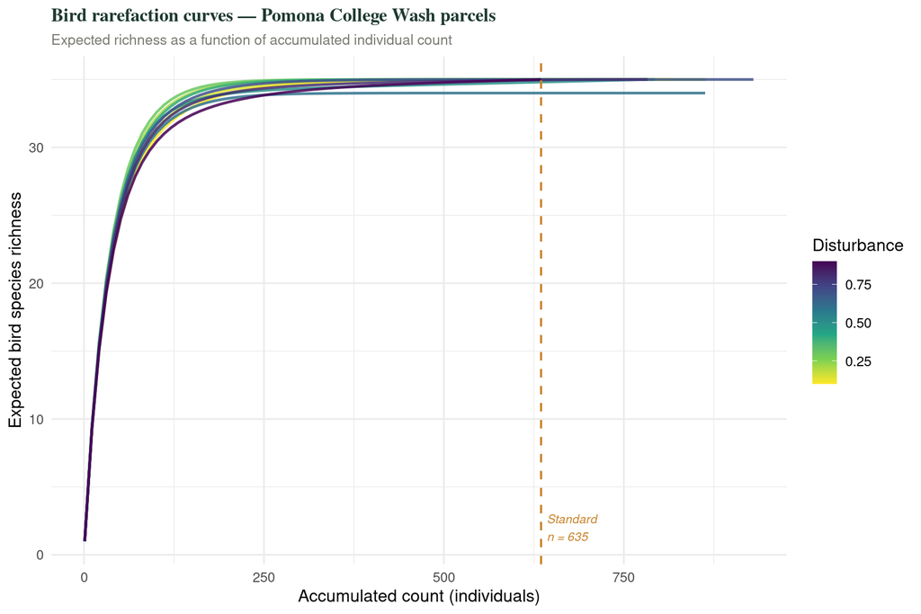

```r
bird_rare_df <- imap_dfr(bird_rare_list, function(curve, idx) {
  tibble(
    parcel_id = rownames(bird_int)[idx],
    n_indiv   = as.integer(attr(curve, "Subsample")),
    richness  = as.numeric(curve)
  )
}) %>%
  left_join(parcel_meta, by = "parcel_id")

ggplot(bird_rare_df,
       aes(x = n_indiv, y = richness,
           color = disturbance, group = parcel_id)) +
  geom_line(linewidth = 0.9, alpha = 0.85) +
  geom_vline(xintercept = bird_std_n, linetype = "dashed",
             color = "#c8832a", linewidth = 0.7) +
  annotate("text", x = bird_std_n + 8, y = 2,
           label = paste0("Standard\nn = ", bird_std_n),
           size = 3, color = "#c8832a", hjust = 0, fontface = "italic") +
  scale_color_viridis_c(option = "viridis", direction = -1,
                        name = "Disturbance") +
  labs(
    title    = "Bird rarefaction curves — Pomona College Wash parcels",
    subtitle = "Expected richness as a function of accumulated individual count",
    x = "Accumulated count (individuals)",
    y = "Expected bird species richness"
  ) +
  theme_minimal(base_size = 12) +
  theme(
    plot.title    = element_text(family = "serif", face = "bold",
                                 color = "#1e3a2f", size = 13),
    plot.subtitle = element_text(color = "#7a7a72", size = 10)
  )
```

```r
bird_rare_S <- rarefy(bird_int, sample = bird_std_n)

tibble(
  parcel_id  = names(bird_rare_S),
  rarefied_S = round(as.numeric(bird_rare_S), 1),
  raw_S      = specnumber(bird_wide)
) %>%
  left_join(parcel_meta, by = "parcel_id") %>%
  arrange(disturbance) %>%
  kbl(caption = paste0("Rarefied bird richness at n = ", bird_std_n,
                       " individuals per parcel"),
      digits = 1) %>%
  kable_styling(bootstrap_options = c("striped", "hover"), full_width = FALSE)
```

Rarefied bird richness at n = 635 individuals per parcel

| parcel_id | rarefied_S | raw_S | restore_age_yr | disturbance |
| --- | --- | --- | --- | --- |
| P01 | 35.0 | 35 | 15 | 0.1 |
| P02 | 35.0 | 35 | 12 | 0.1 |
| P03 | 35.0 | 35 | 10 | 0.2 |
| P04 | 35.0 | 35 | 8 | 0.3 |
| P05 | 35.0 | 35 | 6 | 0.4 |
| P06 | 34.8 | 35 | 5 | 0.5 |
| P07 | 34.0 | 34 | 4 | 0.6 |
| P08 | 35.0 | 35 | 3 | 0.7 |
| P09 | 35.0 | 35 | 2 | 0.8 |
| P10 | 35.0 | 35 | 1 | 0.9 |

### 12.5 Bird diversity indices

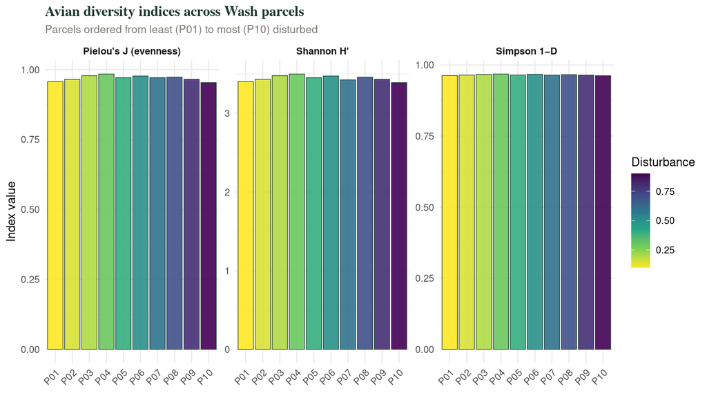

```r
bird_div <- tibble(
  parcel_id  = rownames(bird_wide),
  H_birds    = diversity(bird_wide, index = "shannon"),
  D_birds    = diversity(bird_wide, index = "simpson"),
  S_birds    = specnumber(bird_wide),
  J_birds    = H_birds / log(S_birds)
) %>%
  left_join(parcel_meta, by = "parcel_id") %>%
  pivot_longer(cols = c(H_birds, D_birds, J_birds),
               names_to = "index", values_to = "value") %>%
  mutate(index = recode(index,
    "H_birds" = "Shannon H'",
    "D_birds" = "Simpson 1−D",
    "J_birds"  = "Pielou's J (evenness)"
  ))

ggplot(bird_div,
       aes(x = reorder(parcel_id, disturbance),
           y = value, fill = disturbance)) +
  geom_col(color = "#1e3a2f", linewidth = 0.25, alpha = 0.9) +
  facet_wrap(~ index, scales = "free_y", ncol = 3) +
  scale_fill_viridis_c(option = "viridis", direction = -1,
                       name = "Disturbance") +
  scale_x_discrete(guide = guide_axis(angle = 45)) +
  labs(
    title    = "Avian diversity indices across Wash parcels",
    subtitle = "Parcels ordered from least (P01) to most (P10) disturbed",
    x = NULL, y = "Index value"
  ) +
  theme_minimal(base_size = 11) +
  theme(
    plot.title    = element_text(family = "serif", face = "bold",
                                 color = "#1e3a2f", size = 13),
    plot.subtitle = element_text(color = "#7a7a72", size = 10),
    strip.text    = element_text(face = "bold"),
    legend.position = "right"
  )
```

## 13. Foraging Guild Composition

Diversity indices collapse all species into a single number. But *which* species are present matters biologically — a parcel dominated by invasive European Starlings is ecologically very different from one with equivalent richness driven by riparian specialists. **Foraging guilds** group species by how they feed, providing a functional lens on community change.

### 13.1 Guild proportions across the disturbance gradient

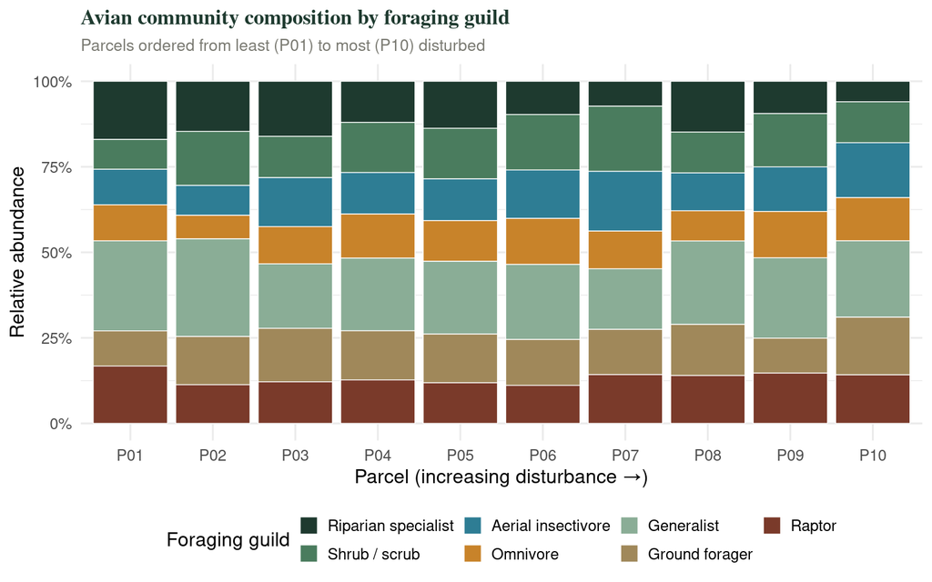

```r
bird_guild_cover <- bird_raw %>%
  group_by(parcel_id, guild_bird) %>%
  summarise(total_count = sum(count), .groups = "drop") %>%
  group_by(parcel_id) %>%
  mutate(rel_count = total_count / sum(total_count)) %>%
  ungroup() %>%
  left_join(parcel_meta, by = "parcel_id") %>%
  mutate(
    parcel_id  = fct_reorder(parcel_id, disturbance),
    guild_bird = factor(guild_bird, levels = c(
      "riparian_specialist", "shrub_scrub", "aerial_insectivore",
      "omnivore", "generalist", "ground_forager", "raptor"
    ))
  )

ggplot(bird_guild_cover,
       aes(x = parcel_id, y = rel_count, fill = guild_bird)) +
  geom_col(color = "white", linewidth = 0.25) +
  scale_fill_manual(
    values = guild_bird_colors,
    labels = c(
      "riparian_specialist" = "Riparian specialist",
      "shrub_scrub"         = "Shrub / scrub",
      "aerial_insectivore"  = "Aerial insectivore",
      "omnivore"            = "Omnivore",
      "generalist"          = "Generalist",
      "ground_forager"      = "Ground forager",
      "raptor"              = "Raptor"
    ),
    name = "Foraging guild"
  ) +
  scale_y_continuous(labels = scales::percent_format()) +
  labs(
    title    = "Avian community composition by foraging guild",
    subtitle = "Parcels ordered from least (P01) to most (P10) disturbed",
    x = "Parcel (increasing disturbance →)", y = "Relative abundance"
  ) +
  theme_minimal(base_size = 12) +
  theme(
    plot.title      = element_text(family = "serif", face = "bold",
                                   color = "#1e3a2f", size = 13),
    plot.subtitle   = element_text(color = "#7a7a72", size = 10),
    legend.position = "bottom",
    legend.key.size = unit(0.4, "cm")
  ) +
  guides(fill = guide_legend(nrow = 2))
```

### 13.2 Indicator species: which birds best characterize each disturbance class?

We can ask, for each species, whether its detection rate differs significantly between low- and high-disturbance parcels using a simple Wilcoxon rank-sum test applied across parcels.

```r
library(broom)

# Classify parcels into low vs. high disturbance (top 5 / bottom 5)
parcel_dist_class <- parcel_meta %>%
  mutate(dist_class = if_else(disturbance <= 0.5, "low", "high"))

# Per-species detection rate per parcel (mean count per station-visit)
bird_rate <- bird_raw %>%
  group_by(parcel_id, species) %>%
  summarise(
    mean_count = sum(count) / (n_visits * n_stations),
    .groups = "drop"
  ) %>%
  left_join(parcel_dist_class, by = "parcel_id")

# Wilcoxon test for each species (low vs. high disturbance)
indicator_tests <- bird_rate %>%
  group_by(species) %>%
  group_modify(~ {
    low  <- .x$mean_count[.x$dist_class == "low"]
    high <- .x$mean_count[.x$dist_class == "high"]
    if (length(unique(c(low, high))) < 2) {
      return(tibble(p_value = NA_real_, W = NA_real_,
                    mean_low = mean(low), mean_high = mean(high)))
    }
    wt <- wilcox.test(low, high, exact = FALSE)
    tibble(p_value = wt$p.value, W = wt$statistic,
           mean_low = mean(low), mean_high = mean(high))
  }) %>%
  ungroup() %>%
  left_join(select(bird_pool, species, guild_bird), by = "species") %>%
  mutate(
    direction = if_else(mean_low > mean_high,
                        "more in low disturbance", "more in high disturbance"),
    p_adj = p.adjust(p_value, method = "BH")   # Benjamini-Hochberg FDR correction
  ) %>%
  filter(!is.na(p_value)) %>%
  arrange(p_adj)

# Show significant indicators (FDR-corrected p < 0.10)
indicator_tests %>%
  filter(p_adj < 0.10) %>%
  select(species, guild_bird, mean_low, mean_high, direction, p_adj) %>%
  mutate(across(where(is.numeric), ~ round(.x, 3))) %>%
  kbl(
    caption = "Indicator species: significant differences between low- and high-disturbance parcels (FDR q < 0.10)",
    col.names = c("Species", "Guild", "Mean rate (low dist.)",
                  "Mean rate (high dist.)", "Direction", "FDR q")
  ) %>%
  kable_styling(bootstrap_options = c("striped", "hover"), full_width = FALSE)
```

Indicator species: significant differences between low- and high-disturbance parcels (FDR q < 0.10)

| Species | Guild | Mean rate (low dist.) | Mean rate (high dist.) | Direction | FDR q |
| --- | --- | --- | --- | --- | --- |

**⚙️ Multiple testing and FDR correction** We are running one Wilcoxon test per species (35 tests). By chance alone, about 5% of tests would be significant at p < 0.05 — roughly 1–2 false positives. The Benjamini-Hochberg procedure controls the **false discovery rate (FDR)**: among all tests called significant, at most 10% (q < 0.10) are expected to be false positives. Always apply multiple-testing correction when comparing many species simultaneously.

## 14. Bird Community Ordination

### 14.1 NMDS of bird assemblages

```r
bird_hel <- decostand(bird_wide, method = "hellinger")

set.seed(77)
bird_nmds <- metaMDS(
  bird_hel,
  distance = "bray",
  k        = 2,
  trymax   = 100,
  autotransform = FALSE
)
```

```r
cat("Bird NMDS stress:", round(bird_nmds$stress, 4), "\n")
```

```
## Bird NMDS stress: 0.1433
```

### 14.2 Overlay vegetation structure as environmental vectors

`envfit()` fits environmental variables as vectors onto the ordination. Variables that explain more of the community variation are drawn as longer arrows pointing in the direction of maximum increase.

```r
# Environmental variables: plant diversity, disturbance, restoration age,
# and native cover fraction from Part I
native_cover_frac <- transect_data %>%
  group_by(parcel_id) %>%
  summarise(
    native_frac = sum(cover_pct[guild %in% c("native_shrub",
                                              "native_grass",
                                              "native_forb")]) /
                  sum(cover_pct),
    shrub_cover = sum(cover_pct[guild == "native_shrub"]) / sum(cover_pct),
    .groups = "drop"
  )

env_vars <- parcel_meta %>%
  left_join(native_cover_frac, by = "parcel_id") %>%
  left_join(
    tibble(
      parcel_id = rownames(bird_wide),
      H_plants  = diversity(comm_wide, index = "shannon")
    ),
    by = "parcel_id"
  ) %>%
  select(parcel_id, disturbance, restore_age_yr,
         native_frac, shrub_cover, H_plants) %>%
  column_to_rownames("parcel_id")

# Reorder rows to match ordination
env_vars <- env_vars[rownames(bird_wide), ]

set.seed(42)
ef <- envfit(bird_nmds, env_vars, permutations = 999, na.rm = TRUE)
print(ef)
```

```
##
## ***VECTORS
##
##                   NMDS1    NMDS2     r2 Pr(>r)
## disturbance     0.97169 -0.23624 0.7880  0.005 **
## restore_age_yr -0.99170  0.12854 0.8395  0.004 **
## native_frac    -0.98748  0.15771 0.8044  0.006 **
## shrub_cover    -0.99800 -0.06318 0.8015  0.004 **
## H_plants        0.69407  0.71991 0.0431  0.848
## ---
## Signif. codes:  0 '***' 0.001 '**' 0.01 '*' 0.05 '.' 0.1 ' ' 1
## Permutation: free
## Number of permutations: 999
```

[figure not shown]

```r
bird_site_scores <- scores(bird_nmds, display = "sites") %>%
  as.data.frame() %>%
  rownames_to_column("parcel_id") %>%
  left_join(parcel_meta, by = "parcel_id")

bird_spp_scores <- scores(bird_nmds, display = "species") %>%
  as.data.frame() %>%
  rownames_to_column("species") %>%
  left_join(bird_pool, by = "species") %>%
  mutate(vec_len = sqrt(NMDS1^2 + NMDS2^2)) %>%
  slice_max(vec_len, n = 10)

# envfit arrow coordinates
ef_df <- as.data.frame(ef$vectors$arrows * sqrt(ef$vectors$r)) %>%
  rownames_to_column("variable") %>%
  mutate(variable = recode(variable,
    "disturbance"    = "Disturbance",
    "restore_age_yr" = "Restoration age",
    "native_frac"    = "Native cover",
    "shrub_cover"    = "Shrub cover",
    "H_plants"       = "Plant diversity H'"
  ))

ggplot() +
  # Species markers
  geom_point(data = bird_spp_scores,
             aes(x = NMDS1, y = NMDS2, color = guild_bird),
             shape = 3, size = 2, stroke = 1.1, alpha = 0.65) +
  geom_text_repel(data = bird_spp_scores,
                  aes(x = NMDS1, y = NMDS2, label = species,
                      color = guild_bird),
                  size = 2.6, fontface = "italic", max.overlaps = 15,
                  segment.color = "grey70", segment.size = 0.3) +
  # Site points
  geom_point(data = bird_site_scores,
             aes(x = NMDS1, y = NMDS2, fill = disturbance,
                 size = restore_age_yr),
             shape = 21, color = "#1e3a2f", stroke = 0.8, alpha = 0.9) +
  geom_text_repel(data = bird_site_scores,
                  aes(x = NMDS1, y = NMDS2, label = parcel_id),
                  size = 3.5, fontface = "bold", color = "#1e3a2f",
                  nudge_y = 0.04) +
  # envfit arrows
  geom_segment(data = ef_df,
               aes(x = 0, y = 0, xend = NMDS1, yend = NMDS2),
               arrow = arrow(length = unit(0.22, "cm"), type = "closed"),
               color = "#c8832a", linewidth = 0.7, alpha = 0.85) +
  geom_text_repel(data = ef_df,
                  aes(x = NMDS1, y = NMDS2, label = variable),
                  color = "#c8832a", size = 3, fontface = "bold",
                  segment.alpha = 0) +
  scale_fill_viridis_c(option = "viridis", direction = -1,
                       name = "Disturbance") +
  scale_color_manual(values = guild_bird_colors, name = "Foraging guild") +
  scale_size_continuous(name = "Restore age\n(yr)", range = c(4, 10)) +
  labs(
    title    = "Bird community NMDS with vegetation covariates",
    subtitle = paste0("Stress = ", round(bird_nmds$stress, 3),
                      "  |  Orange arrows = envfit vectors (p < 0.05)"),
    x = "NMDS 1", y = "NMDS 2"
  ) +
  theme_minimal(base_size = 12) +
  theme(
    plot.title    = element_text(family = "serif", face = "bold",
                                 color = "#1e3a2f", size = 13),
    plot.subtitle = element_text(color = "#7a7a72", size = 10),
    legend.position = "right",
    panel.grid    = element_line(color = "#d4e6da", linewidth = 0.3)
  )
```

**📌 How to read `envfit` vectors** Each orange arrow points in the direction of maximum increase for that environmental variable in the ordination space. The arrow length is proportional to the correlation between that variable and the ordination axes (longer = stronger). A permutation test (999 permutations) tests whether the correlation is stronger than expected by chance. If “Native cover” and “Plant diversity H’” both point in the same direction as the low-disturbance parcels, that is strong evidence that vegetation structure drives bird community composition.

## 15. Cross-taxa Analysis: Do Plant and Bird Communities Track Each Other?

A fundamental question in conservation biology is whether protecting plant diversity also protects animal diversity — the **surrogate species hypothesis**. If the answer is yes, we can use easily-surveyed plants as proxies for harder-to-survey animals. We test this in two ways:

1. **Correlation of diversity indices** — does Shannon H’ for plants correlate with Shannon H’ for birds across parcels?
2. **Mantel test** — are plant community dissimilarities correlated with bird community dissimilarities? (A matrix-level test that accounts for all pairwise relationships.)

### 15.1 Diversity–diversity correlation

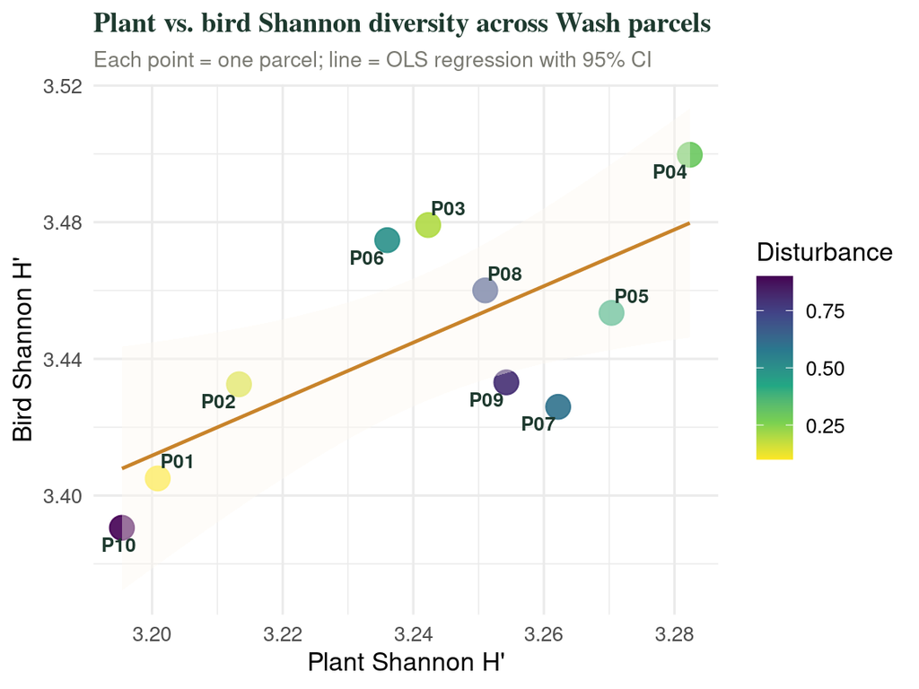

```r
plant_div_wide <- div_df %>%
  pivot_wider(names_from = index, values_from = value) %>%
  select(parcel_id, H_plants = `Shannon H'`)

bird_div_wide <- bird_div %>%
  pivot_wider(names_from = index, values_from = value) %>%
  select(parcel_id, H_birds = `Shannon H'`)

div_compare <- plant_div_wide %>%
  left_join(bird_div_wide, by = "parcel_id") %>%
  left_join(parcel_meta, by = "parcel_id")

ggplot(div_compare,
       aes(x = H_plants, y = H_birds, label = parcel_id,
           color = disturbance)) +
  geom_point(size = 5, alpha = 0.9) +
  geom_smooth(method = "lm", se = TRUE,
              color = "#c8832a", fill = "#fdf8f0", linewidth = 0.8) +
  geom_text_repel(size = 3.2, fontface = "bold", color = "#1e3a2f") +
  scale_color_viridis_c(option = "viridis", direction = -1,
                        name = "Disturbance") +
  labs(
    title    = "Plant vs. bird Shannon diversity across Wash parcels",
    subtitle = "Each point = one parcel; line = OLS regression with 95% CI",
    x = "Plant Shannon H'",
    y = "Bird Shannon H'"
  ) +
  theme_minimal(base_size = 12) +
  theme(
    plot.title    = element_text(family = "serif", face = "bold",
                                 color = "#1e3a2f", size = 13),
    plot.subtitle = element_text(color = "#7a7a72", size = 10)
  )
```

```r
cor_result <- cor.test(div_compare$H_plants, div_compare$H_birds,
                       method = "pearson")
cat(sprintf("\nPearson r = %.3f  (95%% CI: %.3f – %.3f)  p = %.4f\n",
            cor_result$estimate,
            cor_result$conf.int[1],
            cor_result$conf.int[2],
            cor_result$p.value))
```

```
##
## Pearson r = 0.709  (95% CI: 0.144 – 0.926)  p = 0.0216
```

### 15.2 Mantel test: are dissimilarity matrices correlated?

The Mantel test asks whether parcels that are floristically similar (small plant Bray-Curtis distance) also tend to have similar bird communities (small bird Bray-Curtis distance). It tests this using permutations of the matrix labels.

```r
# Distance matrices for plants and birds (Bray-Curtis on Hellinger-transformed data)
plant_dist <- vegdist(decostand(comm_wide, method = "hellinger"),
                      method = "bray")
bird_dist  <- vegdist(bird_hel, method = "bray")

# Ensure same row/column order
plant_dist <- as.dist(as.matrix(plant_dist)[rownames(bird_wide),
                                             rownames(bird_wide)])

set.seed(123)
mantel_result <- mantel(plant_dist, bird_dist,
                        method = "pearson",
                        permutations = 999)
print(mantel_result)
```

```
##
## Mantel statistic based on Pearson's product-moment correlation
##
## Call:
## mantel(xdis = plant_dist, ydis = bird_dist, method = "pearson",      permutations = 999)
##
## Mantel statistic r: 0.4682
##       Significance: 0.007
##
## Upper quantiles of permutations (null model):
##   90%   95% 97.5%   99%
## 0.253 0.307 0.371 0.420
## Permutation: free
## Number of permutations: 999
```

**📌 Interpreting the Mantel test** The Mantel statistic r measures the correlation between corresponding elements of the two distance matrices — one entry per parcel pair. If plant community dissimilarity consistently predicts bird community dissimilarity, r will be positive and significantly different from zero. A significant positive Mantel r would support using plant diversity surveys as a proxy for bird diversity in the Wash restoration program.

### 15.3 Side-by-side summary: plants vs. birds

```r
bird_div_sum <- tibble(
  parcel_id = rownames(bird_wide),
  H_birds   = diversity(bird_wide, index = "shannon"),
  S_birds   = specnumber(bird_wide),
  rarefied_birds = round(as.numeric(rarefy(bird_int, bird_std_n)), 1)
) %>%
  left_join(parcel_meta, by = "parcel_id")

cross_tbl <- plant_div_wide %>%
  left_join(bird_div_sum, by = "parcel_id") %>%
  left_join(
    tibble(parcel_id = names(rare_S),
           S_plants  = specnumber(comm_wide),
           rarefied_plants = round(as.numeric(rare_S), 1)),
    by = "parcel_id"
  ) %>%
  arrange(disturbance) %>%
  select(parcel_id, disturbance,
         S_plants, rarefied_plants, H_plants,
         S_birds, rarefied_birds, H_birds) %>%
  mutate(across(where(is.numeric), ~ round(.x, 2)))

cross_tbl %>%
  kbl(
    caption = "Side-by-side plant and bird diversity metrics by parcel",
    col.names = c("Parcel", "Disturbance",
                  "Plant S", "Plant S (rarefied)", "Plant H'",
                  "Bird S", "Bird S (rarefied)", "Bird H'")
  ) %>%
  kable_styling(bootstrap_options = c("striped", "hover", "condensed"),
                full_width = FALSE) %>%
  add_header_above(c(" " = 2,
                     "Plants (Part I)" = 3,
                     "Birds (Part II)" = 3)) %>%
  column_spec(2, color = "white",
              background = spec_color(cross_tbl$disturbance,
                                      palette = "viridis",
                                      direction = -1))
```

Side-by-side plant and bird diversity metrics by parcel

| Parcel | Disturbance | Plants (Part I) Plant S | Plants (Part I) Plant S (rarefied) | Plants (Part I) Plant H’ | Birds (Part II) Bird S | Birds (Part II) Bird S (rarefied) | Birds (Part II) Bird H’ |
| --- | --- | --- | --- | --- | --- | --- | --- |
| P01 | 0.10 | 28 | 28 | 3.20 | 35 | 35.0 | 3.40 |
| P02 | 0.15 | 28 | 28 | 3.21 | 35 | 35.0 | 3.43 |
| P03 | 0.20 | 28 | 28 | 3.24 | 35 | 35.0 | 3.48 |
| P04 | 0.30 | 28 | 28 | 3.28 | 35 | 35.0 | 3.50 |
| P05 | 0.40 | 28 | 28 | 3.27 | 35 | 35.0 | 3.45 |
| P06 | 0.50 | 28 | 28 | 3.24 | 35 | 34.8 | 3.47 |
| P07 | 0.60 | 28 | 28 | 3.26 | 34 | 34.0 | 3.43 |
| P08 | 0.70 | 28 | 28 | 3.25 | 35 | 35.0 | 3.46 |
| P09 | 0.80 | 28 | 28 | 3.25 | 35 | 35.0 | 3.43 |
| P10 | 0.90 | 28 | 28 | 3.20 | 35 | 35.0 | 3.39 |